# *Heart Attack Analysis & Prediction*

Data Source: https://archive.ics.uci.edu/ml/datasets/Heart+Disease

```python
from google.colab import drive
drive.mount('/content/drive')
```

```python
import numpy as np
import pandas as pd
```

```python
#df = pd.read_csv('/content/drive/MyDrive/heart-disease-uci-dataset.csv')
df = pd.read_csv('https://raw.githubusercontent.com/sharmaroshan/Heart-UCI-Dataset/master/heart.csv')
```

```python
# Exploring the first 5 rows of the dataset
df.head()
```

|  | age | sex | cp | trestbps | chol | fbs | restecg | thalach | exang | oldpeak | slope | ca | thal | target |
| --- | --- | --- | --- | --- | --- | --- | --- | --- | --- | --- | --- | --- | --- | --- |
| 0 | 63 | 1 | 3 | 145 | 233 | 1 | 0 | 150 | 0 | 2.3 | 0 | 0 | 1 | 1 |
| 1 | 37 | 1 | 2 | 130 | 250 | 0 | 1 | 187 | 0 | 3.5 | 0 | 0 | 2 | 1 |
| 2 | 41 | 0 | 1 | 130 | 204 | 0 | 0 | 172 | 0 | 1.4 | 2 | 0 | 2 | 1 |
| 3 | 56 | 1 | 1 | 120 | 236 | 0 | 1 | 178 | 0 | 0.8 | 2 | 0 | 2 | 1 |
| 4 | 57 | 0 | 0 | 120 | 354 | 0 | 1 | 163 | 1 | 0.6 | 2 | 0 | 2 | 1 |

```python
# Exploring the last 5 rows of the dataset
df.tail()
```

|  | age | sex | cp | trestbps | chol | fbs | restecg | thalach | exang | oldpeak | slope | ca | thal | target |
| --- | --- | --- | --- | --- | --- | --- | --- | --- | --- | --- | --- | --- | --- | --- |
| 298 | 57 | 0 | 0 | 140 | 241 | 0 | 1 | 123 | 1 | 0.2 | 1 | 0 | 3 | 0 |
| 299 | 45 | 1 | 3 | 110 | 264 | 0 | 1 | 132 | 0 | 1.2 | 1 | 0 | 3 | 0 |
| 300 | 68 | 1 | 0 | 144 | 193 | 1 | 1 | 141 | 0 | 3.4 | 1 | 2 | 3 | 0 |
| 301 | 57 | 1 | 0 | 130 | 131 | 0 | 1 | 115 | 1 | 1.2 | 1 | 1 | 3 | 0 |
| 302 | 57 | 0 | 1 | 130 | 236 | 0 | 0 | 174 | 0 | 0.0 | 1 | 1 | 2 | 0 |

```python
#Printing the Dimensions of the dataframe (rows, columns)
#It shows the number of rows and columns in a dataset
print(df.shape)
```

```
(303, 14)
```

```python
df.info()
```

```
<class 'pandas.core.frame.DataFrame'>
RangeIndex: 303 entries, 0 to 302
Data columns (total 14 columns):
 #   Column    Non-Null Count  Dtype
---  ------    --------------  -----
 0   age       303 non-null    int64
 1   sex       303 non-null    int64
 2   cp        303 non-null    int64
 3   trestbps  303 non-null    int64
 4   chol      303 non-null    int64
 5   fbs       303 non-null    int64
 6   restecg   303 non-null    int64
 7   thalach   303 non-null    int64
 8   exang     303 non-null    int64
 9   oldpeak   303 non-null    float64
 10  slope     303 non-null    int64
 11  ca        303 non-null    int64
 12  thal      303 non-null    int64
 13  target    303 non-null    int64
dtypes: float64(1), int64(13)
memory usage: 33.3 KB
```

```python
# Exploring the statistics of the dataset
df.describe()
```

|  | age | sex | cp | trestbps | chol | fbs | restecg | thalach | exang | oldpeak | slope | ca | thal | target |
| --- | --- | --- | --- | --- | --- | --- | --- | --- | --- | --- | --- | --- | --- | --- |
| count | 303.000000 | 303.000000 | 303.000000 | 303.000000 | 303.000000 | 303.000000 | 303.000000 | 303.000000 | 303.000000 | 303.000000 | 303.000000 | 303.000000 | 303.000000 | 303.000000 |
| mean | 54.366337 | 0.683168 | 0.966997 | 131.623762 | 246.264026 | 0.148515 | 0.528053 | 149.646865 | 0.326733 | 1.039604 | 1.399340 | 0.729373 | 2.313531 | 0.544554 |
| std | 9.082101 | 0.466011 | 1.032052 | 17.538143 | 51.830751 | 0.356198 | 0.525860 | 22.905161 | 0.469794 | 1.161075 | 0.616226 | 1.022606 | 0.612277 | 0.498835 |
| min | 29.000000 | 0.000000 | 0.000000 | 94.000000 | 126.000000 | 0.000000 | 0.000000 | 71.000000 | 0.000000 | 0.000000 | 0.000000 | 0.000000 | 0.000000 | 0.000000 |
| 25% | 47.500000 | 0.000000 | 0.000000 | 120.000000 | 211.000000 | 0.000000 | 0.000000 | 133.500000 | 0.000000 | 0.000000 | 1.000000 | 0.000000 | 2.000000 | 0.000000 |
| 50% | 55.000000 | 1.000000 | 1.000000 | 130.000000 | 240.000000 | 0.000000 | 1.000000 | 153.000000 | 0.000000 | 0.800000 | 1.000000 | 0.000000 | 2.000000 | 1.000000 |
| 75% | 61.000000 | 1.000000 | 2.000000 | 140.000000 | 274.500000 | 0.000000 | 1.000000 | 166.000000 | 1.000000 | 1.600000 | 2.000000 | 1.000000 | 3.000000 | 1.000000 |
| max | 77.000000 | 1.000000 | 3.000000 | 200.000000 | 564.000000 | 1.000000 | 2.000000 | 202.000000 | 1.000000 | 6.200000 | 2.000000 | 4.000000 | 3.000000 | 1.000000 |

```python
!pip install pandas-profiling
import pandas_profiling as pp
pp.ProfileReport(df)
```

[output not shown]

[interactive chart not shown]

## *2. Exploratory Data Analysis*

```python
df_cleaned = df.copy()
```

```python
# Unit Tests
assert isinstance(df_cleaned, pd.DataFrame)
assert df_cleaned.shape == df.shape
```

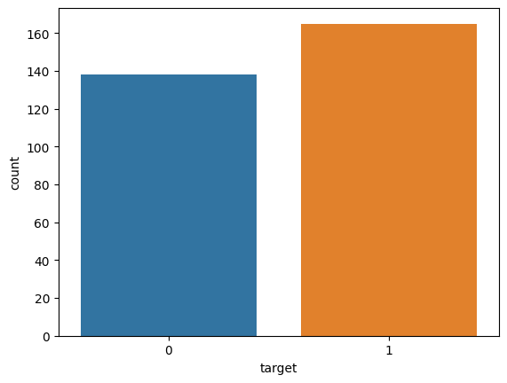

```python
# Exploring the distribution of the target variable
import seaborn as sns
sns.countplot(x="target", data=df_cleaned)
```

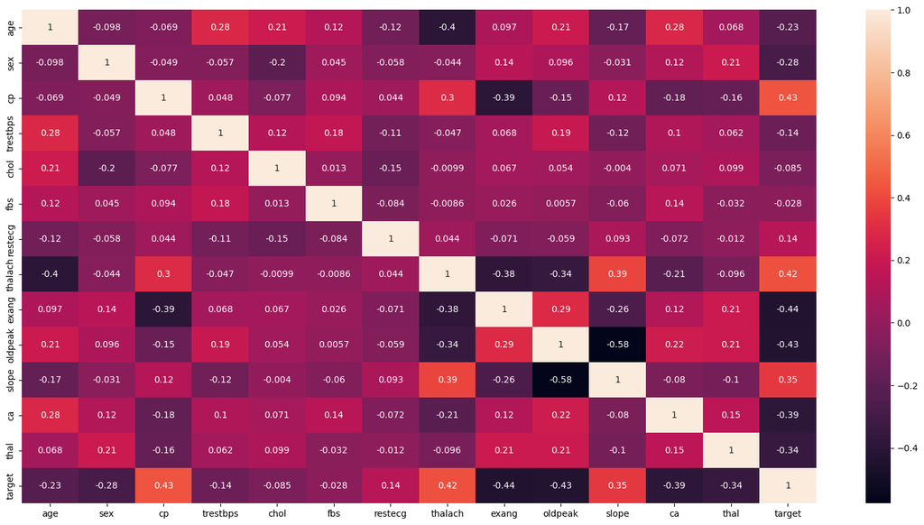

```python
# Exploring the correlation between variables using a heatmap
import matplotlib.pyplot as plt
plt.figure(figsize=(20,10))
sns.heatmap(df_cleaned.corr(), annot=True)
```

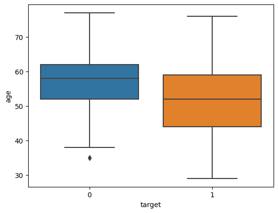

```python
# Exploring the relationship between age and target variable
sns.boxplot(x='target', y='age', data=df_cleaned)
```

The relationship between age and the target variable (presence or absence of heart disease) tells us whether there is an association between age and the risk of developing heart disease. In the exploratory data analysis code provided earlier, this relationship is explored using a boxplot.

If the boxplot shows that there is a significant difference in age between the two groups (presence or absence of heart disease), then it suggests that age may be a significant factor in predicting the presence of heart disease. For example, if the boxplot shows that individuals with heart disease tend to be older than those without heart disease, it suggests that age may be a risk factor for developing heart disease.

On the other hand, if the boxplot shows no significant difference in age between the two groups, then age may not be a significant factor in predicting the presence of heart disease. However, this does not necessarily mean that age is not a risk factor for heart disease, as there may be other factors that influence the relationship between age and heart disease.

Overall, exploring the relationship between age and the target variable is an important step in understanding the risk factors associated with heart disease and can provide valuable insights for developing effective prevention and treatment strategies.

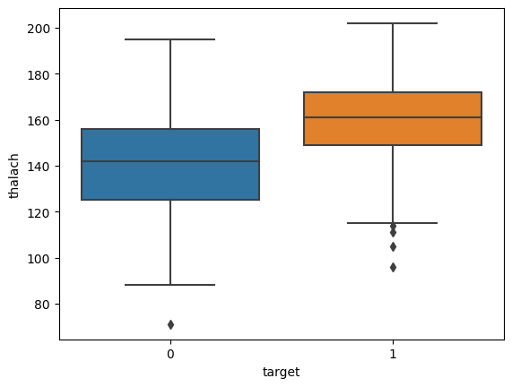

```python
# Exploring the relationship between maximum heart rate achieved and target variable
sns.boxplot(x='target', y='thalach', data=df_cleaned)
```

Exploring the relationship between maximum heart rate achieved and the target variable tells us whether there is an association between maximum heart rate achieved and the risk of developing heart disease. The boxplot helps us to understand if individuals with heart disease have a significantly different maximum heart rate achieved compared to those without heart disease. If there is a significant difference, it suggests that maximum heart rate achieved could be a potential predictor of heart disease. This information can be used to develop effective prevention and treatment strategies for heart disease.

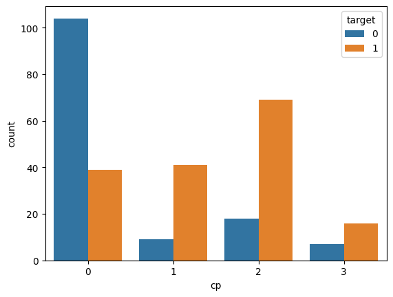

```python
# Exploring the relationship between chest pain type and target variable
sns.countplot(x='cp', hue='target', data=df_cleaned)
```

Exploring the relationship between chest pain type and the target variable tells us whether there is an association between the type of chest pain experienced by individuals and the risk of developing heart disease. This information can provide insights into potential symptoms and risk factors associated with heart disease.

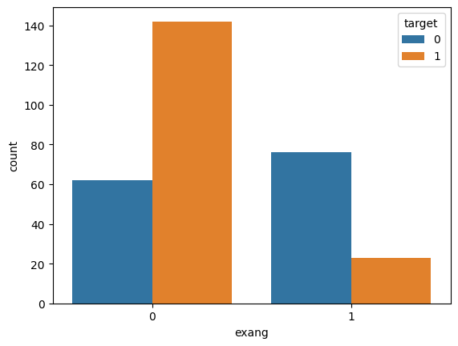

```python
# Exploring the relationship between exercise induced angina and target variable
sns.countplot(x='exang', hue='target', data=df_cleaned)
```

Exploring the relationship between exercise-induced angina and the target variable can provide valuable insights into the association between chest pain or discomfort during exercise and the risk of developing heart disease. By analyzing this relationship, we can identify potential symptoms and risk factors associated with heart disease, such as reduced blood flow to the heart during exercise. This information can be used to develop effective prevention and treatment strategies for heart disease and improve overall patient outcomes.

# Training the model - Decision Tree

```python
from sklearn.model_selection import train_test_split
from sklearn.tree import DecisionTreeClassifier
from sklearn.metrics import classification_report, confusion_matrix
from sklearn.model_selection import GridSearchCV

# Define features and target
X = df_cleaned.drop(columns='target')
y = df_cleaned['target']

# Split the data
X_train, X_test, y_train, y_test = train_test_split(X, y, test_size=0.2, random_state=42)

# Define the model
dt = DecisionTreeClassifier(random_state=42)

# Define the hyperparameters to tune
param_grid = {'max_depth': range(1, 10), 'min_samples_split': range(2, 10)}

# Use GridSearchCV to find the best hyperparameters
grid_search = GridSearchCV(dt, param_grid, cv=5)

# Train the model
grid_search.fit(X_train, y_train)

# Print the best parameters found
print(grid_search.best_params_)

# Use the best model to make predictions
best_dt = grid_search.best_estimator_
y_pred = best_dt.predict(X_test)

# Print the classification report and confusion matrix
print(classification_report(y_test, y_pred))
print(confusion_matrix(y_test, y_pred))
```

```
{'max_depth': 6, 'min_samples_split': 2}
              precision    recall  f1-score   support

           0       0.81      0.86      0.83        29
           1       0.87      0.81      0.84        32

    accuracy                           0.84        61
   macro avg       0.84      0.84      0.84        61
weighted avg       0.84      0.84      0.84        61

[[25  4]
 [ 6 26]]
```

The classification report and confusion matrix generated for the Decision Tree model suggest that it is performing fairly well with an accuracy of 84%.

Looking at the confusion matrix, we can see that the model has:

- True Positive (TP): 26 (patients with heart disease correctly identified as having the disease)
- True Negative (TN): 25 (patients without heart disease correctly identified as not having the disease)
- False Positive (FP): 4 (patients without heart disease incorrectly identified as having the disease)
- False Negative (FN): 6 (patients with heart disease incorrectly identified as not having the disease)